# DJIA

2023-03-13

The Dow Jones Industrial Average (DJIA), Dow Jones, or simply the Dow, is a stock market index of 30 prominent companies listed on stock exchanges in the United States. Firstly, by consulting EDA on DJIA, we try to answer the following questions. How have yields and trading volumes changed over the years? How have yields and trading volumes fluctuated over the years?

#data description ##data loading and required packages

Using the getSymbols () function provided in the quantmod package, we can obtain the Industrial average index from 2007 to the end of 2018.

```r
load("~/Desktop/pre/DJI.RData")
dim(DJI)
```

```
## [1] 3020    6
```

```r
class(DJI)
```

```
## [1] "xts" "zoo"
```

We have available OHLC (open, high, Low, close) index values, adjusted closing prices, and trading volume.

```r
head(DJI)
```

```
##            DJI.Open DJI.High  DJI.Low DJI.Close DJI.Volume DJI.Adjusted
## 2007-01-03 12459.54 12580.35 12404.82  12474.52  327200000     12474.52
## 2007-01-04 12473.16 12510.41 12403.86  12480.69  259060000     12480.69
## 2007-01-05 12480.05 12480.13 12365.41  12398.01  235220000     12398.01
## 2007-01-08 12392.01 12445.92 12337.37  12423.49  223500000     12423.49
## 2007-01-09 12424.77 12466.43 12369.17  12416.60  225190000     12416.60
## 2007-01-10 12417.00 12451.61 12355.63  12442.16  226570000     12442.16
```

```r
tail(DJI)
```

```
##            DJI.Open DJI.High  DJI.Low DJI.Close DJI.Volume DJI.Adjusted
## 2018-12-21 22871.74 23254.59 22396.34  22445.37  900510000     22445.37
## 2018-12-24 22317.28 22339.87 21792.20  21792.20  308420000     21792.20
## 2018-12-26 21857.73 22878.92 21712.53  22878.45  433080000     22878.45
## 2018-12-27 22629.06 23138.89 22267.42  23138.82  407940000     23138.82
## 2018-12-28 23213.61 23381.88 22981.33  23062.40  336510000     23062.40
## 2018-12-31 23153.94 23333.18 23118.30  23327.46  288830000     23327.46
```

Here, we can see the corresponding graph generated.

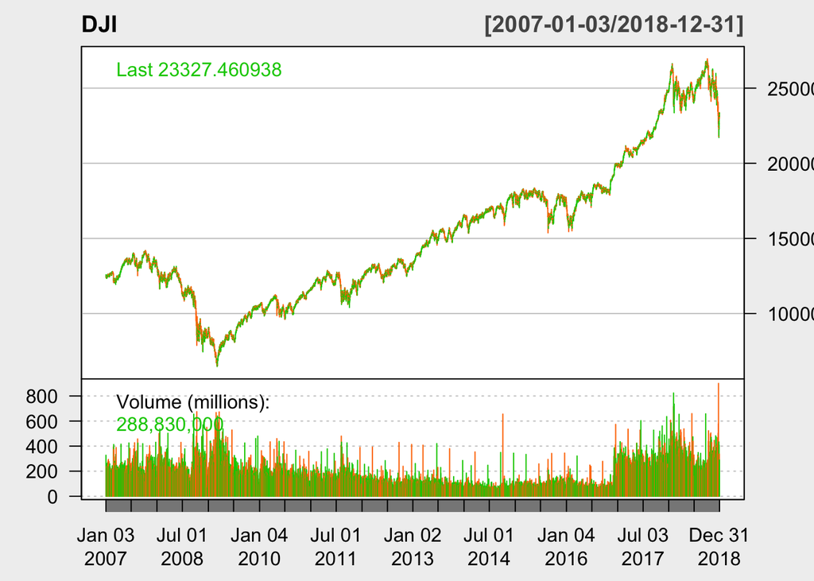

```r
chartSeries(DJI, type = "bars", theme="white")
```

We analyze the adjusted closing prices here.

```r
dj_close <- DJI[,"DJI.Adjusted"]
```

The definition of return:$R_t=\frac{P_t-P_{t-1}}{P_{t-1}}=\frac{P_t}{P_{t-1}}-1$. The definition of log-return:$r_t=ln\frac{P_t}{P_t-1}=ln(1+R_t)$. We calculate the log-return.

```r
dj_ret <- CalculateReturns(dj_close, method = "log")
dj_ret <- na.omit(dj_ret)
head(dj_ret)
```

```
##             DJI.Adjusted
## 2007-01-04  0.0004945580
## 2007-01-05 -0.0066467273
## 2007-01-08  0.0020530973
## 2007-01-09 -0.0005547987
## 2007-01-10  0.0020564627
## 2007-01-11  0.0058356461
```

```r
tail(dj_ret)
```

```
##            DJI.Adjusted
## 2018-12-21 -0.018286825
## 2018-12-24 -0.029532247
## 2018-12-26  0.048643314
## 2018-12-27  0.011316355
## 2018-12-28 -0.003308137
## 2018-12-31  0.011427645
```

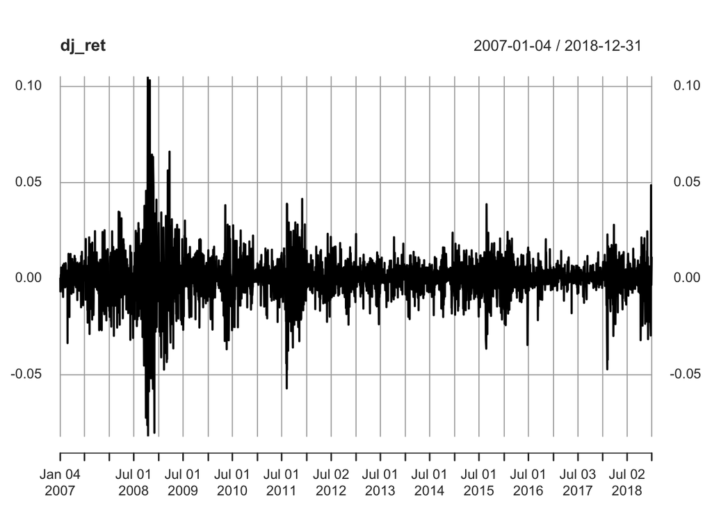

```r
plot(dj_ret)
```

We need some auxiliary functions to simplify some basic data conversion, summarization, and plotting.

```r
# 1.从xts转换为带有year and value列的数据框。这样就可以进行年度总结和绘制。
xts_to_dataframe <- function(data_xts) {
  df_t <- data.frame(year = factor(year(index(data_xts))), value = coredata(data_xts))
  colnames(df_t) <- c( "year", "value")
  df_t
}

# 2.摘要统计信息，用于存储为数据框列的数据。
bs_rn <- rownames(basicStats(rnorm(10,0,1))) # 基本统计数据输出行名称
dataframe_basicstats <- function(dataset) {
  result <- with(dataset, tapply(value, year, basicStats))
  df_result <- do.call(cbind, result)
  rownames(df_result) <- bs_rn
  as.data.frame(df_result)
}

# 3.返回关联的列名。
filter_dj_stats <- function(dataset_basicstats, metricname, threshold) {
  r <- which(rownames(dataset_basicstats) ==  metricname)
  colnames(dataset_basicstats[r, which(dataset_basicstats[r,] > threshold), drop = FALSE])
}

# 4.基于年的面板箱线图。
dataframe_boxplot <- function(dataset, title) {
  p <- ggplot(data = dataset, aes(x = year, y = value)) + theme_bw() + theme(legend.position = "none") + geom_boxplot(fill = "lightblue")
  p <- p + theme(axis.text.x = element_text(angle = 90, hjust = 1)) + ggtitle(title) + ylab("year")
  p
}

# 5.密度图，以年份为基准。
dataframe_densityplot <- function(dataset, title) {
  p <- ggplot(data = dataset, aes(x = value)) + geom_density(fill = "lightblue")
  p <- p + facet_wrap(. ~ year)
  p <- p + theme_bw() + theme(legend.position = "none") + ggtitle(title)
  p
}

# 6.基于年份的QQ图。
dataframe_qqplot <- function(dataset, title) {
  p <- ggplot(data = dataset, aes(sample = value)) + stat_qq(colour = "blue") + stat_qq_line()
  p <- p + facet_wrap(. ~ year)
  p <- p + theme_bw() + theme(legend.position = "none") + ggtitle(title)
  p
}

# 7. Shapiro测试
shp_pvalue <- function (v) {
  shapiro.test(v)$p.value
}
dataframe_shapirotest <- function(dataset) {
  result <- with(dataset, tapply(value, year, shp_pvalue))
  as.data.frame(result)
}
```

##Exploratory data analysis of log-return ###Exploratory data analysis of daily log-return We convert the original time series into a data box with year and value columns. This simplifies the drawing and summary by year.

```r
dj_ret_df <- xts_to_dataframe(dj_ret)
head(dj_ret_df)
```

```
##   year         value
## 1 2007  0.0004945580
## 2 2007 -0.0066467273
## 3 2007  0.0020530973
## 4 2007 -0.0005547987
## 5 2007  0.0020564627
## 6 2007  0.0058356461
```

```r
tail(dj_ret_df)
```

```
##      year        value
## 3014 2018 -0.018286825
## 3015 2018 -0.029532247
## 3016 2018  0.048643314
## 3017 2018  0.011316355
## 3018 2018 -0.003308137
## 3019 2018  0.011427645
```

We gave the basic statistical summary.

```r
(dj_stats <- dataframe_basicstats(dj_ret_df))
```

```
##                   2007       2008       2009       2010       2011       2012
## nobs        250.000000 253.000000 252.000000 252.000000 252.000000 250.000000
## NAs           0.000000   0.000000   0.000000   0.000000   0.000000   0.000000
## Minimum      -0.033488  -0.082005  -0.047286  -0.036700  -0.057061  -0.023910
## Maximum       0.025223   0.105083   0.066116   0.038247   0.041533   0.023376
## 1. Quartile  -0.003802  -0.012993  -0.006897  -0.003853  -0.006193  -0.003896
## 3. Quartile   0.005230   0.007843   0.008248   0.004457   0.006531   0.004924
## Mean          0.000246  -0.001633   0.000684   0.000415   0.000214   0.000280
## Median        0.001098  -0.000890   0.001082   0.000681   0.000941  -0.000122
## Sum           0.061427  -0.413050   0.172434   0.104565   0.053810   0.070054
## SE Mean       0.000582   0.001497   0.000960   0.000641   0.000837   0.000470
## LCL Mean     -0.000900  -0.004580  -0.001207  -0.000848  -0.001434  -0.000645
## UCL Mean      0.001391   0.001315   0.002575   0.001678   0.001861   0.001206
## Variance      0.000085   0.000567   0.000232   0.000104   0.000176   0.000055
## Stdev         0.009197   0.023808   0.015242   0.010182   0.013283   0.007429
## Skewness     -0.613828   0.224042   0.070840  -0.174816  -0.526083   0.027235
## Kurtosis      1.525069   3.670796   2.074240   2.055407   2.453822   0.842890
##                   2013       2014       2015       2016       2017       2018
## nobs        252.000000 252.000000 252.000000 252.000000 251.000000 251.000000
## NAs           0.000000   0.000000   0.000000   0.000000   0.000000   0.000000
## Minimum      -0.023695  -0.020988  -0.036402  -0.034473  -0.017930  -0.047143
## Maximum       0.023263   0.023982   0.038755   0.024384   0.014468   0.048643
## 1. Quartile  -0.002812  -0.002621  -0.005283  -0.002845  -0.001404  -0.005017
## 3. Quartile   0.004750   0.004230   0.005801   0.004311   0.003054   0.005895
## Mean          0.000933   0.000288  -0.000090   0.000500   0.000892  -0.000231
## Median        0.001158   0.000728  -0.000211   0.000738   0.000655   0.000695
## Sum           0.235068   0.072498  -0.022586   0.125884   0.223790  -0.057950
## SE Mean       0.000403   0.000432   0.000613   0.000501   0.000263   0.000714
## LCL Mean      0.000139  -0.000564  -0.001298  -0.000487   0.000373  -0.001637
## UCL Mean      0.001727   0.001139   0.001118   0.001486   0.001410   0.001175
## Variance      0.000041   0.000047   0.000095   0.000063   0.000017   0.000128
## Stdev         0.006399   0.006861   0.009738   0.007951   0.004172   0.011313
## Skewness     -0.199407  -0.332766  -0.127788  -0.449311  -0.189808  -0.522618
## Kurtosis      1.275821   1.073234   1.394268   2.079671   2.244076   2.802996
```

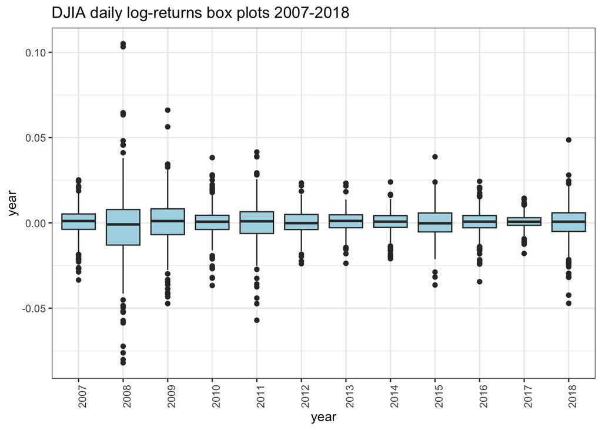

```r
dataframe_boxplot(dj_ret_df, "DJIA daily log-returns box plots 2007-2018")
```

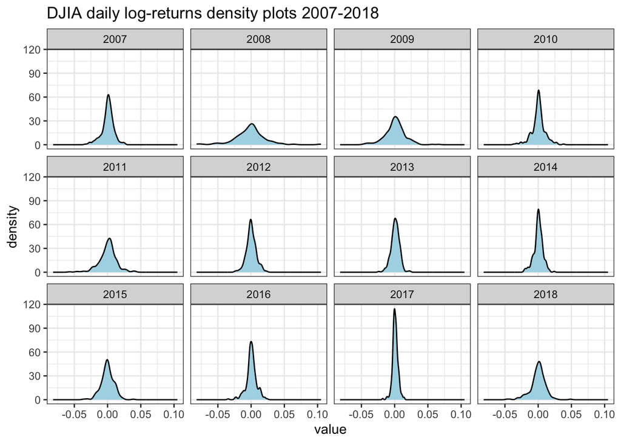

```r
dataframe_densityplot(dj_ret_df, "DJIA daily log-returns density plots 2007-2018")
```

```r
dataframe_shapirotest(dj_ret_df)
```

```
##            result
## 2007 5.989576e-07
## 2008 5.782666e-09
## 2009 1.827967e-05
## 2010 3.897345e-07
## 2011 5.494349e-07
## 2012 1.790685e-02
## 2013 8.102500e-03
## 2014 1.750036e-04
## 2015 5.531137e-03
## 2016 1.511435e-06
## 2017 3.304529e-05
## 2018 1.216327e-07
```

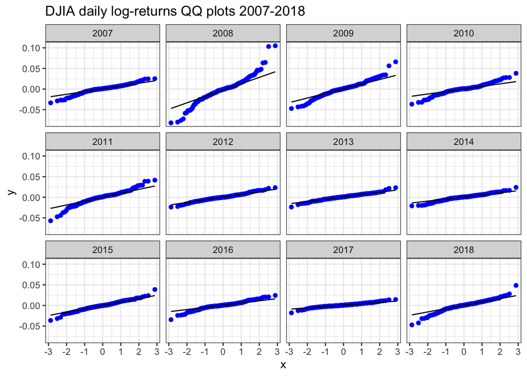

```r
dataframe_qqplot(dj_ret_df, "DJIA daily log-returns QQ plots 2007-2018")
```

###Exploratory data analysis of weekly log-return We can calculate the weekly log-return by starting with the daily log-return. We analyze the trading week of {t-4, t-3, t-2, t-1, t} days and know the closing price on day t-5 (the last day of the previous week). We define the weekly logarithmic return as: $r_t^w=ln\frac{P_t}{P_{t-5}}=ln\frac{P_tP_{t-1}P_{t-2}P_{t-3}P_{t-4}}{P_{t-1}P_{t-2}P_{t-3}P_{t-4}P_{t-5}}=ln\frac{P_t}{P_{t-1}}+ln\frac{P_{t-1}}{P_{t-2}}+ln\frac{P_{t-2}}{P_{t-3}}+ln\frac{P_{t-3}}{P_{t-4}}+ln\frac{P_{t-4}}{P_{t-5}}=r_t+r_{t-1}+r_{t-2}+r_{t-3}+r_{t-4}$

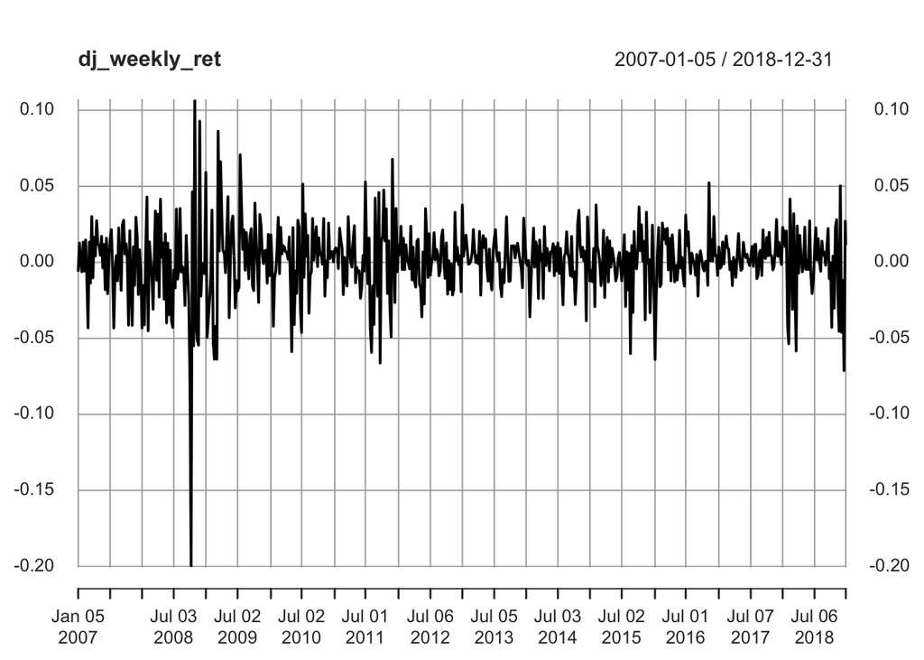

```r
dj_weekly_ret <- apply.weekly(dj_ret, sum)
plot(dj_weekly_ret)
```

```r
dj_weekly_ret_df <- xts_to_dataframe(dj_weekly_ret)
dim(dj_weekly_ret_df)
```

```
## [1] 627   2
```

```r
head(dj_weekly_ret_df)
```

```
##   year         value
## 1 2007 -0.0061521694
## 2 2007  0.0126690596
## 3 2007  0.0007523559
## 4 2007 -0.0062677053
## 5 2007  0.0132434177
## 6 2007 -0.0057588519
```

```r
tail(dj_weekly_ret_df)
```

```
##     year       value
## 622 2018  0.05028763
## 623 2018 -0.04605546
## 624 2018 -0.01189714
## 625 2018 -0.07114867
## 626 2018  0.02711928
## 627 2018  0.01142764
```

We gave the basic statistical summary.

```r
(dj_stats <- dataframe_basicstats(dj_weekly_ret_df))
```

```
##                  2007      2008      2009      2010      2011      2012
## nobs        52.000000 52.000000 53.000000 52.000000 52.000000 52.000000
## NAs          0.000000  0.000000  0.000000  0.000000  0.000000  0.000000
## Minimum     -0.043199 -0.200298 -0.063736 -0.058755 -0.066235 -0.035829
## Maximum      0.030143  0.106977  0.086263  0.051463  0.067788  0.035316
## 1. Quartile -0.009638 -0.031765 -0.015911 -0.007761 -0.015485 -0.010096
## 3. Quartile  0.014808  0.012682  0.022115  0.016971  0.014309  0.011887
## Mean         0.001327 -0.008669  0.003823  0.002011  0.001035  0.001102
## Median       0.004244 -0.006811  0.004633  0.004529  0.001757  0.001166
## Sum          0.069016 -0.450811  0.202605  0.104565  0.053810  0.057303
## SE Mean      0.002613  0.006164  0.004454  0.003031  0.003836  0.002133
## LCL Mean    -0.003919 -0.021043 -0.005115 -0.004074 -0.006666 -0.003181
## UCL Mean     0.006573  0.003704  0.012760  0.008096  0.008736  0.005384
## Variance     0.000355  0.001975  0.001051  0.000478  0.000765  0.000237
## Stdev        0.018843  0.044446  0.032424  0.021856  0.027662  0.015382
## Skewness    -0.680573 -0.985740  0.121331 -0.601407 -0.076579 -0.027302
## Kurtosis    -0.085887  5.446623 -0.033398  0.357708  0.052429 -0.461228
##                  2013      2014      2015      2016      2017      2018
## nobs        52.000000 52.000000 53.000000 52.000000 52.000000 53.000000
## NAs          0.000000  0.000000  0.000000  0.000000  0.000000  0.000000
## Minimum     -0.022556 -0.038482 -0.059991 -0.063897 -0.015317 -0.071149
## Maximum      0.037702  0.034224  0.037693  0.052243  0.028192  0.050288
## 1. Quartile -0.001738 -0.006378 -0.012141 -0.007746 -0.002251 -0.011897
## 3. Quartile  0.011432  0.010244  0.009620  0.012791  0.009891  0.019857
## Mean         0.004651  0.001756 -0.000669  0.002421  0.004304 -0.001093
## Median       0.006360  0.003961  0.000954  0.001947  0.004080  0.001546
## Sum          0.241874  0.091300 -0.035444  0.125884  0.223790 -0.057950
## SE Mean      0.001828  0.002151  0.002609  0.002436  0.001232  0.003592
## LCL Mean     0.000981 -0.002563 -0.005904 -0.002470  0.001830 -0.008302
## UCL Mean     0.008322  0.006075  0.004567  0.007312  0.006778  0.006115
## Variance     0.000174  0.000241  0.000361  0.000309  0.000079  0.000684
## Stdev        0.013185  0.015514  0.018995  0.017568  0.008886  0.026154
## Skewness    -0.035175 -0.534403 -0.494963 -0.467158  0.266281 -0.658951
## Kurtosis    -0.200282  0.282354  0.665460  2.908942 -0.124341 -0.000870
```

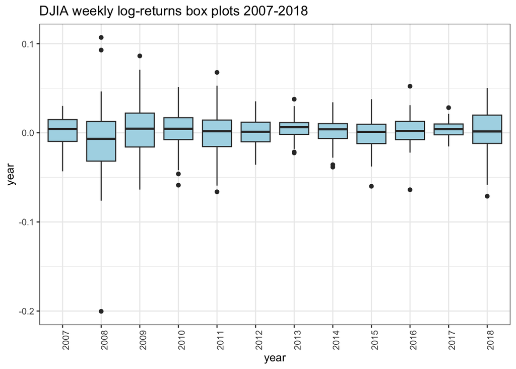

```r
dataframe_boxplot(dj_weekly_ret_df, "DJIA weekly log-returns box plots 2007-2018")
```

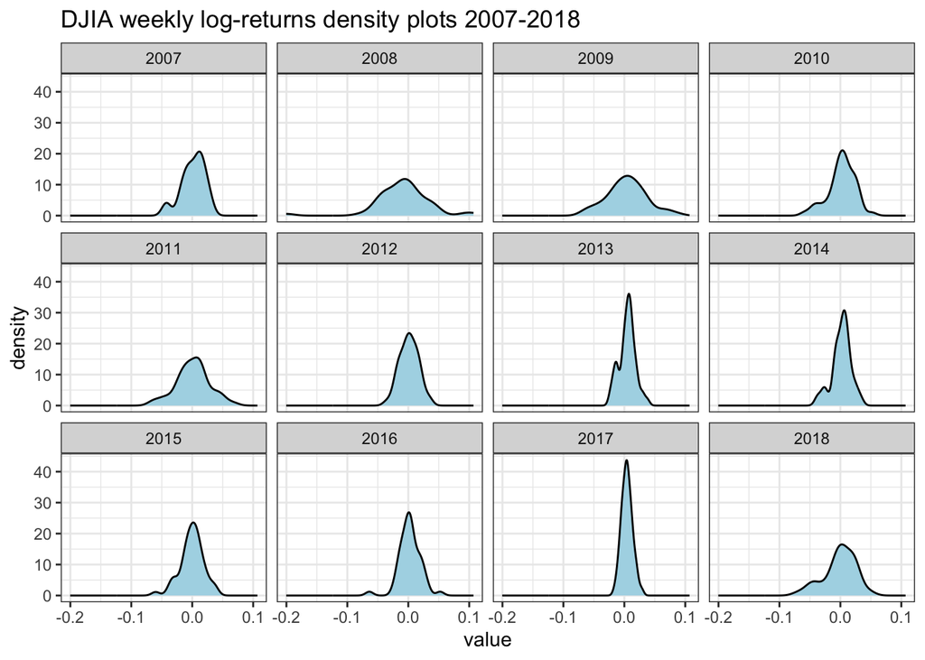

```r
dataframe_densityplot(dj_weekly_ret_df, "DJIA weekly log-returns density plots 2007-2018")
```

```r
dataframe_shapirotest(dj_weekly_ret_df)
```

```
##            result
## 2007 0.0140590311
## 2008 0.0001397267
## 2009 0.8701335006
## 2010 0.0927104389
## 2011 0.8650874270
## 2012 0.9934600084
## 2013 0.4849043121
## 2014 0.1123139646
## 2015 0.3141519756
## 2016 0.0115380989
## 2017 0.9465281164
## 2018 0.0475141869
```

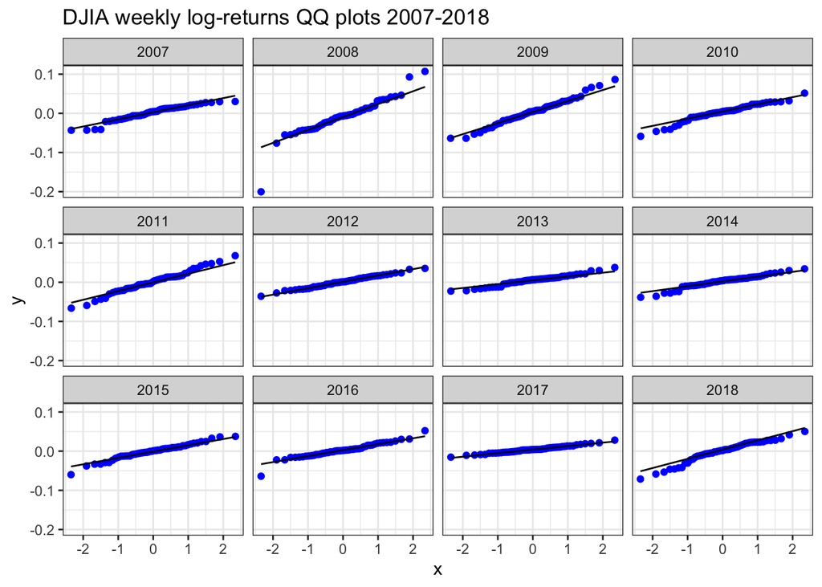

```r
dataframe_qqplot(dj_weekly_ret_df, "DJIA weekly log-returns QQ plots 2007-2018")
```

##Exploratory data analysis of volumn ###Exploratory data analysis of daily volumn

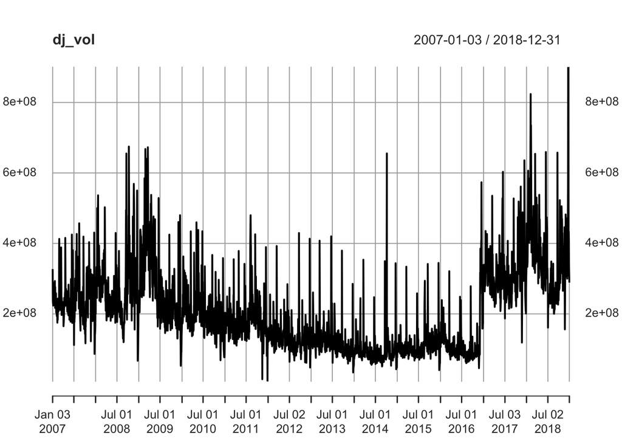

```r
dj_vol <- DJI[,"DJI.Volume"]
plot(dj_vol)
```

```r
dj_vol_df <- xts_to_dataframe(dj_vol)
head(dj_vol_df)
```

```
##   year     value
## 1 2007 327200000
## 2 2007 259060000
## 3 2007 235220000
## 4 2007 223500000
## 5 2007 225190000
## 6 2007 226570000
```

```r
tail(dj_vol_df)
```

```
##      year     value
## 3015 2018 900510000
## 3016 2018 308420000
## 3017 2018 433080000
## 3018 2018 407940000
## 3019 2018 336510000
## 3020 2018 288830000
```

The basic statistical summary

```r
(dj_stats <- dataframe_basicstats(dj_vol_df))
```

```
##                     2007         2008         2009         2010         2011
## nobs        2.510000e+02 2.530000e+02 2.520000e+02 2.520000e+02 2.520000e+02
## NAs         0.000000e+00 0.000000e+00 0.000000e+00 0.000000e+00 0.000000e+00
## Minimum     8.640000e+07 6.693000e+07 5.267000e+07 6.840000e+07 8.410000e+06
## Maximum     4.571500e+08 6.749200e+08 6.729500e+08 4.598900e+08 4.799800e+08
## 1. Quartile 2.063000e+08 2.132100e+08 1.961850e+08 1.633400e+08 1.458775e+08
## 3. Quartile 2.727400e+08 3.210100e+08 3.353625e+08 2.219025e+08 1.932400e+08
## Mean        2.449575e+08 2.767164e+08 2.800537e+08 2.017934e+08 1.804133e+08
## Median      2.350900e+08 2.569700e+08 2.443200e+08 1.905050e+08 1.671250e+08
## Sum         6.148432e+10 7.000924e+10 7.057354e+10 5.085193e+10 4.546415e+10
## SE Mean     3.842261e+06 5.965786e+06 7.289666e+06 3.950031e+06 3.897738e+06
## LCL Mean    2.373901e+08 2.649672e+08 2.656970e+08 1.940139e+08 1.727369e+08
## UCL Mean    2.525248e+08 2.884655e+08 2.944104e+08 2.095728e+08 1.880897e+08
## Variance    3.705505e+15 9.004422e+15 1.339109e+16 3.931891e+15 3.828475e+15
## Stdev       6.087286e+07 9.489163e+07 1.157199e+08 6.270480e+07 6.187468e+07
## Skewness    9.422400e-01 1.203283e+00 1.037015e+00 1.452082e+00 1.878239e+00
## Kurtosis    1.482540e+00 2.064821e+00 6.584810e-01 3.214065e+00 5.631080e+00
##                     2012         2013         2014         2015         2016
## nobs        2.500000e+02 2.520000e+02 2.520000e+02 2.520000e+02 2.520000e+02
## NAs         0.000000e+00 0.000000e+00 0.000000e+00 0.000000e+00 0.000000e+00
## Minimum     4.771000e+07 3.364000e+07 4.287000e+07 4.035000e+07 4.589000e+07
## Maximum     4.296100e+08 4.200800e+08 6.554500e+08 3.445600e+08 5.734700e+08
## 1. Quartile 1.107150e+08 9.488000e+07 7.283000e+07 8.775250e+07 8.224250e+07
## 3. Quartile 1.421775e+08 1.297575e+08 9.928000e+07 1.192150e+08 1.203550e+08
## Mean        1.312606e+08 1.184434e+08 9.288516e+07 1.093957e+08 1.172089e+08
## Median      1.251950e+08 1.109250e+08 8.144500e+07 1.021000e+08 9.410500e+07
## Sum         3.281515e+10 2.984773e+10 2.340706e+10 2.756772e+10 2.953664e+10
## SE Mean     2.796503e+06 2.809128e+06 3.282643e+06 2.433611e+06 4.331290e+06
## LCL Mean    1.257528e+08 1.129109e+08 8.642012e+07 1.046028e+08 1.086786e+08
## UCL Mean    1.367684e+08 1.239758e+08 9.935019e+07 1.141886e+08 1.257392e+08
## Variance    1.955108e+15 1.988583e+15 2.715488e+15 1.492461e+15 4.727538e+15
## Stdev       4.421660e+07 4.459353e+07 5.211034e+07 3.863238e+07 6.875709e+07
## Skewness    3.454971e+00 3.551752e+00 6.619268e+00 3.420032e+00 3.046742e+00
## Kurtosis    1.852581e+01 1.900989e+01 5.856136e+01 1.612326e+01 1.122161e+01
##                     2017         2018
## nobs        2.510000e+02 2.510000e+02
## NAs         0.000000e+00 0.000000e+00
## Minimum     1.186100e+08 1.559400e+08
## Maximum     6.357400e+08 9.005100e+08
## 1. Quartile 2.695850e+08 2.819550e+08
## 3. Quartile 3.389950e+08 4.179200e+08
## Mean        3.112414e+08 3.593710e+08
## Median      2.996700e+08 3.414700e+08
## Sum         7.812159e+10 9.020213e+10
## SE Mean     4.376392e+06 6.984484e+06
## LCL Mean    3.026221e+08 3.456151e+08
## UCL Mean    3.198607e+08 3.731270e+08
## Variance    4.807356e+15 1.224454e+16
## Stdev       6.933510e+07 1.106550e+08
## Skewness    1.478680e+00 1.363823e+00
## Kurtosis    3.848708e+00 3.277164e+00
```

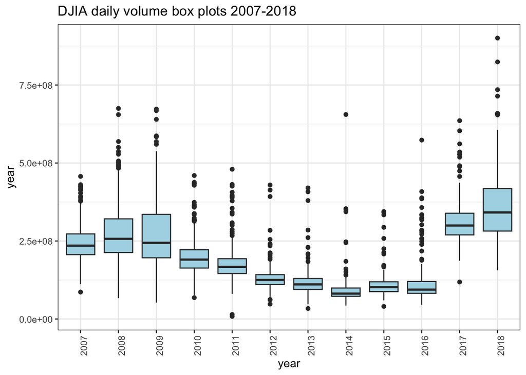

```r
dataframe_boxplot(dj_vol_df, "DJIA daily volume box plots 2007-2018")
```

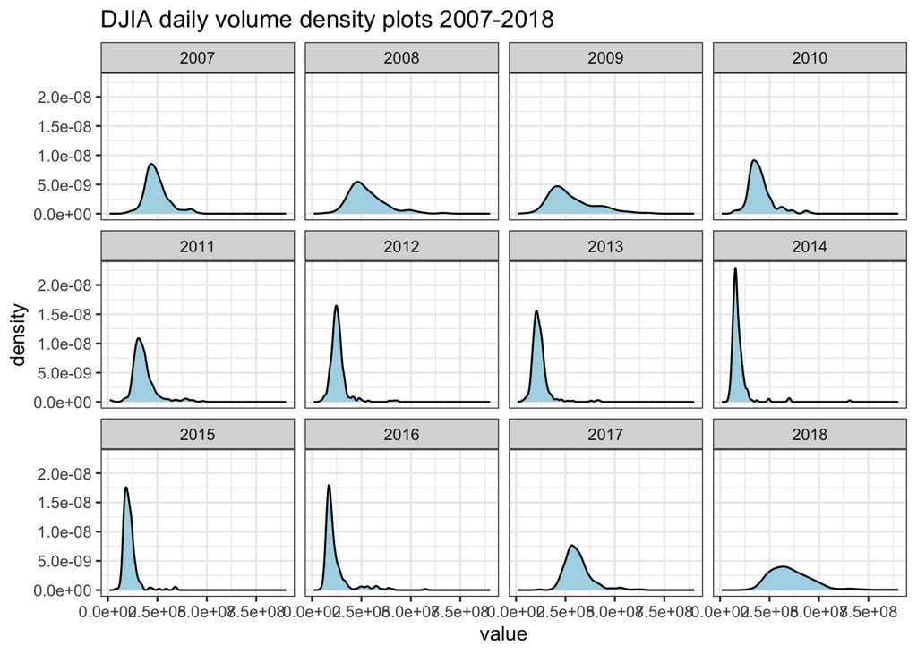

```r
dataframe_densityplot(dj_vol_df, "DJIA daily volume density plots 2007-2018")
```

```r
dataframe_shapirotest(dj_vol_df)
```

```
##            result
## 2007 6.608332e-09
## 2008 3.555102e-10
## 2009 1.023147e-10
## 2010 9.890576e-13
## 2011 2.681476e-16
## 2012 1.866544e-20
## 2013 6.906596e-21
## 2014 5.304227e-27
## 2015 2.739912e-21
## 2016 6.640215e-23
## 2017 4.547310e-12
## 2018 9.288371e-11
```

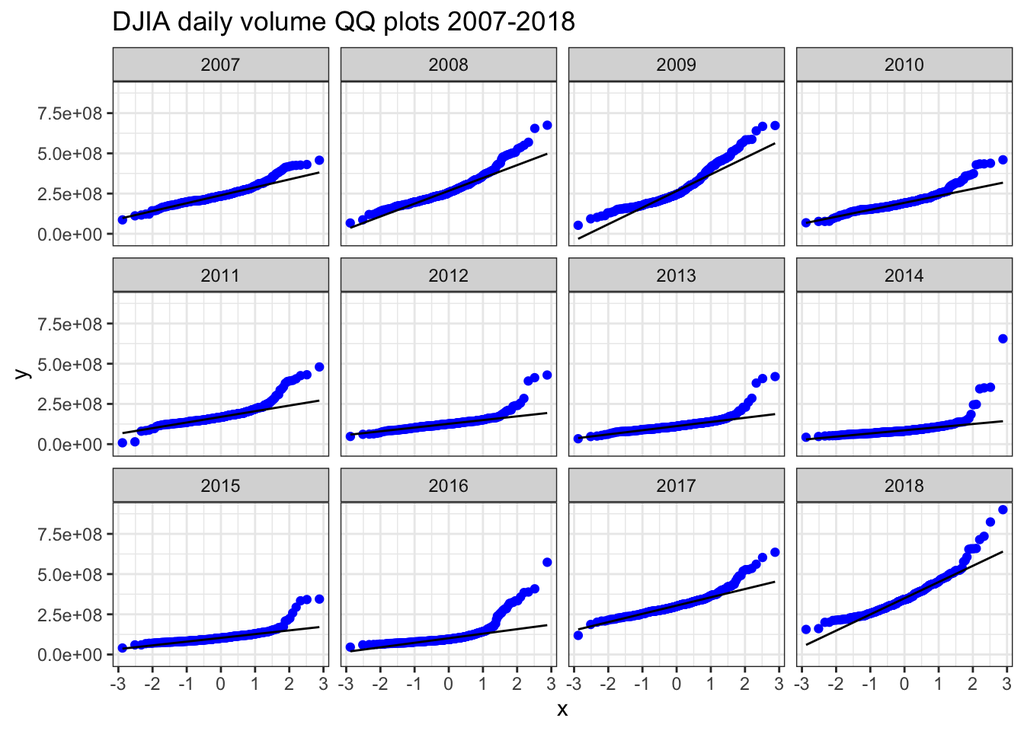

```r
dataframe_qqplot(dj_vol_df, "DJIA daily volume QQ plots 2007-2018")
```

Similar to log-return, we can define the log-ratio of trading volume as: $v_t=ln\frac{V_t}{V_{t-1}}$ We can calculate and graph it through the “CalculateReturns” in the “PerformanceAnalytics” package.

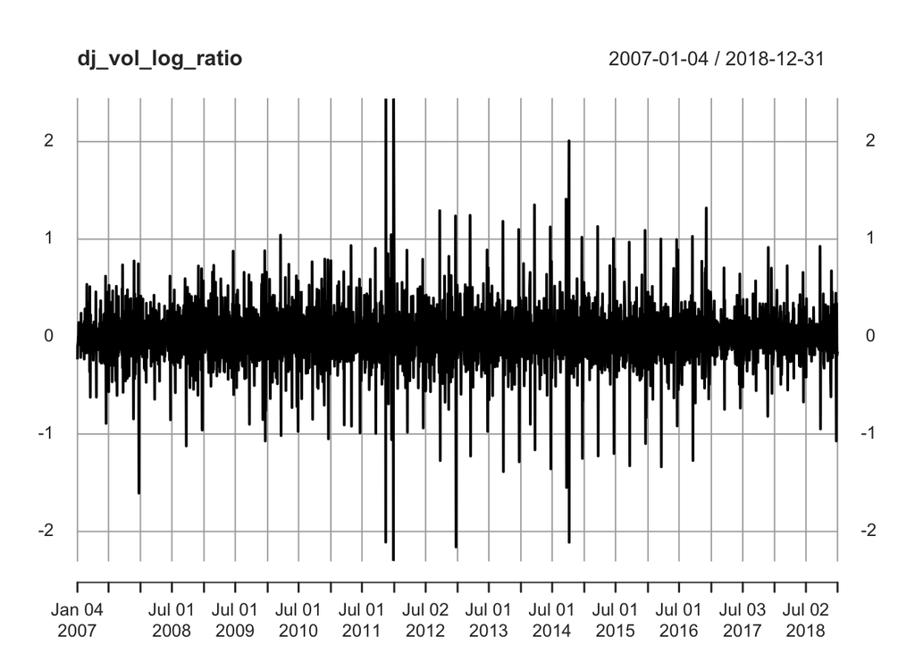

```r
dj_vol_log_ratio <- CalculateReturns(dj_vol, "log")
dj_vol_log_ratio <- na.omit(dj_vol_log_ratio)
plot(dj_vol_log_ratio)
```

```r
dj_vol_df <- xts_to_dataframe(dj_vol_log_ratio)
head(dj_vol_df)
```

```
##   year        value
## 1 2007 -0.233511910
## 2 2007 -0.096538449
## 3 2007 -0.051109832
## 4 2007  0.007533076
## 5 2007  0.006109458
## 6 2007  0.144221282
```

the basic statistical summary

```r
(dj_stats <- dataframe_basicstats(dj_vol_df))
```

```
##                   2007       2008       2009       2010       2011       2012
## nobs        250.000000 253.000000 252.000000 252.000000 252.000000 250.000000
## NAs           0.000000   0.000000   0.000000   0.000000   0.000000   0.000000
## Minimum      -1.606192  -1.122526  -1.071225  -1.050181  -2.301514  -2.158960
## Maximum       0.775961   0.724762   0.881352   1.041216   2.441882   1.292956
## 1. Quartile  -0.123124  -0.128815  -0.162191  -0.170486  -0.157758  -0.152899
## 3. Quartile   0.130056   0.145512   0.169233   0.179903   0.137108   0.144257
## Mean         -0.002685   0.001203  -0.001973  -0.001550   0.000140   0.001642
## Median       -0.010972   0.002222  -0.031748  -0.004217  -0.012839  -0.000010
## Sum          -0.671142   0.304462  -0.497073  -0.390677   0.035162   0.410521
## SE Mean       0.016984   0.016196   0.017618   0.019318   0.026038   0.021293
## LCL Mean     -0.036135  -0.030693  -0.036670  -0.039596  -0.051141  -0.040295
## UCL Mean      0.030766   0.033100   0.032725   0.036495   0.051420   0.043579
## Variance      0.072112   0.066364   0.078219   0.094041   0.170850   0.113345
## Stdev         0.268536   0.257612   0.279677   0.306661   0.413341   0.336667
## Skewness     -0.802037  -0.632586   0.066535  -0.150523   0.407226  -0.878227
## Kurtosis      5.345212   2.616615   1.500979   1.353797  14.554642   8.115847
##                   2013       2014       2015       2016       2017       2018
## nobs        252.000000 252.000000 252.000000 252.000000 251.000000 251.000000
## NAs           0.000000   0.000000   0.000000   0.000000   0.000000   0.000000
## Minimum      -1.386215  -2.110572  -1.326016  -1.336471  -0.817978  -1.071499
## Maximum       1.245202   2.008667   1.130289   1.319713   0.915599   0.926101
## 1. Quartile  -0.145444  -0.144280  -0.143969  -0.134011  -0.112190  -0.119086
## 3. Quartile   0.149787   0.134198   0.150003   0.141287   0.110989   0.112424
## Mean         -0.002442   0.000200   0.000488   0.004228  -0.000017   0.000257
## Median       -0.004922   0.013460   0.004112  -0.002044  -0.006322   0.003987
## Sum          -0.615419   0.050506   0.123080   1.065480  -0.004238   0.064605
## SE Mean       0.019799   0.023514   0.019010   0.019089   0.013446   0.014180
## LCL Mean     -0.041435  -0.046110  -0.036952  -0.033367  -0.026500  -0.027671
## UCL Mean      0.036551   0.046510   0.037929   0.041823   0.026466   0.028185
## Variance      0.098784   0.139334   0.091071   0.091826   0.045383   0.050471
## Stdev         0.314299   0.373274   0.301780   0.303028   0.213032   0.224658
## Skewness     -0.297951  -0.209417  -0.285918   0.083826   0.088511  -0.281007
## Kurtosis      4.681120   9.850061   4.754926   4.647785   3.411062   4.335748
```

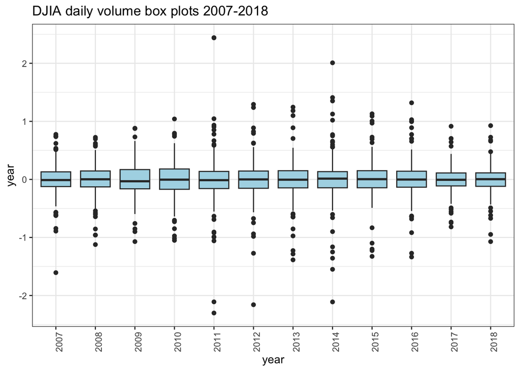

```r
dataframe_boxplot(dj_vol_df, "DJIA daily volume box plots 2007-2018")
```

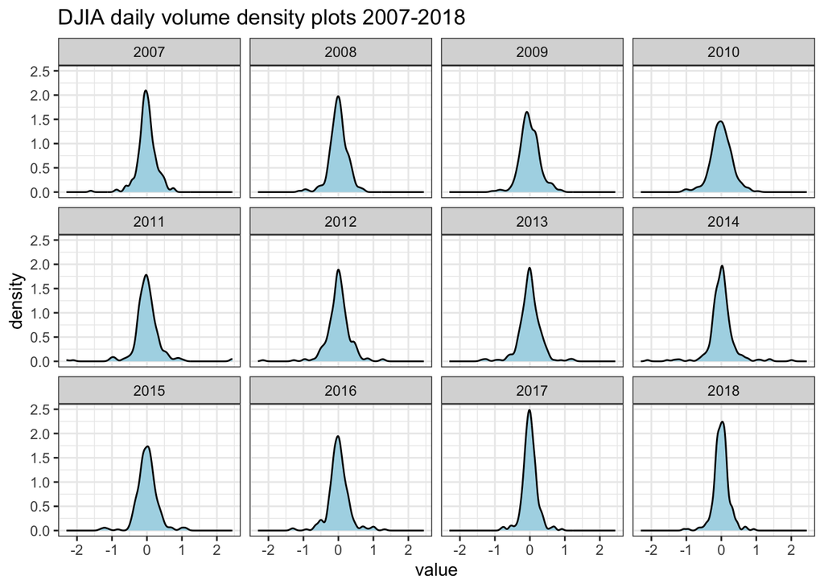

```r
dataframe_densityplot(dj_vol_df, "DJIA daily volume density plots 2007-2018")
```

```r
dataframe_shapirotest(dj_vol_df)
```

```
##            result
## 2007 3.695053e-09
## 2008 6.160136e-07
## 2009 2.083475e-04
## 2010 1.500060e-03
## 2011 3.434415e-18
## 2012 8.417627e-12
## 2013 1.165184e-10
## 2014 1.954662e-16
## 2015 5.261037e-11
## 2016 7.144940e-11
## 2017 1.550661e-08
## 2018 3.069196e-09
```

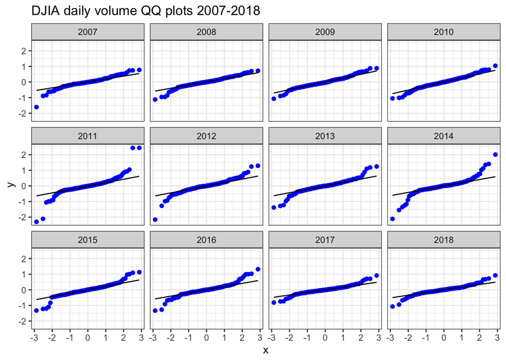

```r
dataframe_qqplot(dj_vol_df, "DJIA daily volume QQ plots 2007-2018")
```

#furure plan 1. How do we model yield volatility?–Build an ARMA-GARCH model for the daily log-return of DJIA. 2. How do we simulate fluctuations in trading volume?–Build an ARMA-GARCH model for the daily log-ratio of trading volume of DJIA.